# Ejemplo-03

## Inicio al modelaje de datos

### OBJETIVO

- Algoritmo Random Forest

#### REQUISITOS

1. Contar con R studio.
2. Usar la carpeta de trabajo `Sesion08/Ejemplo-03`

#### DESARROLLO

El modelo random forest se basa en los arboles de decision; estos se definen como modelos para clasificar un caso. Para cada arbol, un numero aleatorio de casos se va a generar de todas las posibles situaciones y, a su vez, un nodo de posibles desenlaces para cada uno de ellos. Vamos a crear un modelo de clasificacion de vinos. Leemos la data del link ‘http://archive.ics.uci.edu/ml/machine-learning-databases/wine/wine.data’ e importamos los packages que usaremos (ggplot2 y randomForest)

```r
library("randomForest")
library(ggplot2)
vinos <- 'http://archive.ics.uci.edu/ml/machine-learning-databases/wine/wine.data'
```

Reconfiguraremos los datos para leerlos como tabla e indicar que no incluye cabeceras:

```r
vinos <- read.table(file=url(vinos), header=FALSE, sep=",")
```

Ahora crearemos los nombres de las columnas:

```r
columnas <- c('clase',
            'alcohol',
            'malic_acid',
            'ash',
            'ash_alcalinidad',
            'magnesio',
            'total_phenols',
            'flavanoids',
            'nonflavanoid_phenols',
            'proanthocyanins',
            'color',
            'hue',
            'od280_od315',
            'proline')
```

Crearemos los nombres de las columnas que hemos definido a nuestra base de vinos y convertiremos a factor la clase, ya que es la variable segun la que tomaremos decisiones.

```r
names(vinos) <- columnas
vinos$clase <- as.factor(vinos$clase)
```

Creamos una muestra aleatoria de 31 y creamos muestra y muestra_2, nuestras dos bases aleatorias de igual tamano.

```r
set.seed(31)
muestra <- sort(sample(x = 1:nrow(vinos), replace = FALSE, size = nrow(vinos)/2))
muestra_2 <- setdiff(1:nrow(vinos), muestra)
```

Con ellas, extraeremos el test y training set:

```r
test <- vinos[muestra, ]
train <- vinos[muestra_2, ]
```

Aplicamos el modelo de random forest para la variable clase:

```r
randfor <- randomForest(clase ~ ., data=train, importance=TRUE, do.trace=100)
```

```
ntree      OOB      1      2      3
  100:   1.12%  0.00%  2.94%  0.00%
  200:   2.25%  0.00%  5.88%  0.00%
  300:   2.25%  0.00%  5.88%  0.00%
  400:   2.25%  0.00%  5.88%  0.00%
  500:   2.25%  0.00%  5.88%  0.00%
```

Ahora mediremos la importancia para cada una de las clases y lo graficaremos:

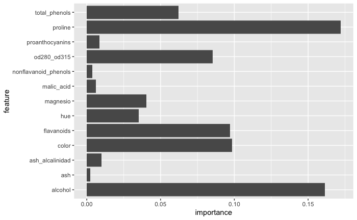

```r
clase1_importance <- data.frame(feature=names(randfor$importance[,1]), importance=randfor$importance[,1])
ggplot(clase1_importance, aes(x=feature, y=importance)) + geom_bar(stat="identity") + coord_flip()
```

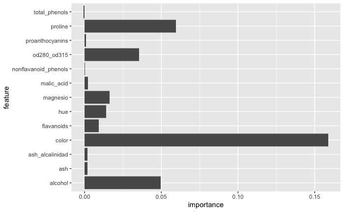

```r
clase2_importance <- data.frame(feature=names(randfor$importance[,2]), importance=randfor$importance[,2])
ggplot(clase2_importance, aes(x=feature, y=importance)) + geom_bar(stat="identity") + coord_flip()
```

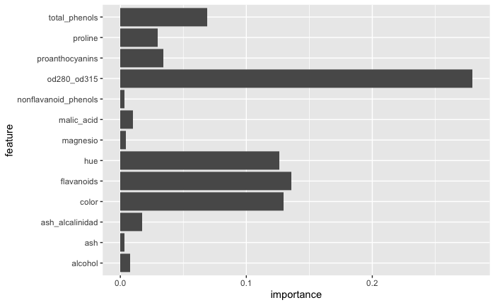

```r
clase3_importance <- data.frame(feature=names(randfor$importance[,3]), importance=randfor$importance[,3])
ggplot(clase3_importance, aes(x=feature, y=importance)) + geom_bar(stat="identity") + coord_flip()
```

Mediante un boxplot, veremos el impacto del color en cada clase y el del alcohol

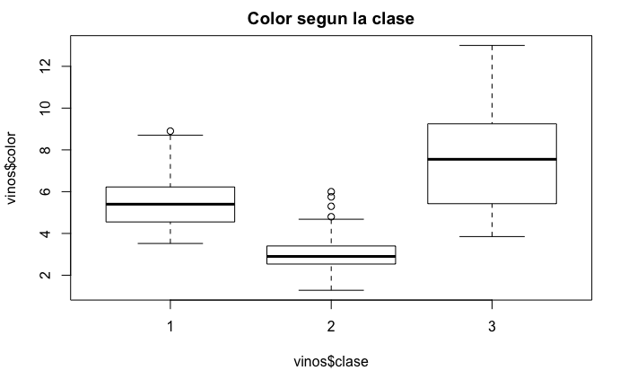

```r
boxplot(vinos$color ~ vinos$clase, main="Color segun la clase")
```

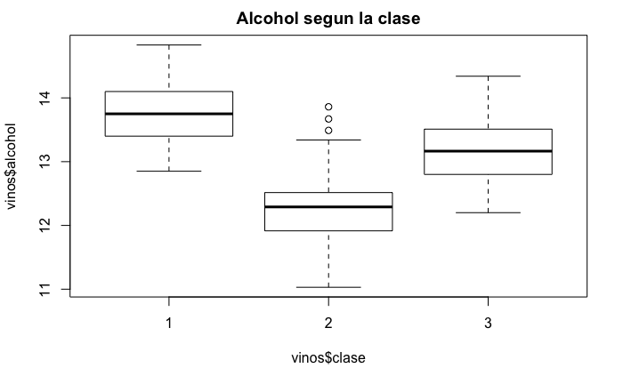

```r
boxplot(vinos$alcohol ~ vinos$clase, main="Alcohol segun la clase")
```

Finalmente, veremos la conexión entre ambas variables (alcohol y color) segun cada clase:

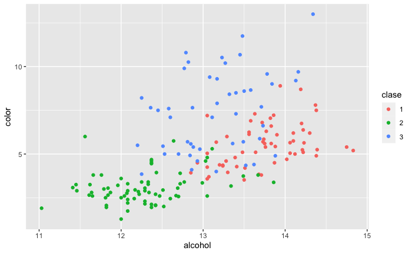

```r
ggplot(vinos, aes(x=alcohol, y=color, colour=clase)) + geom_point()
```